# Introdução ao R - Sessão 4.1

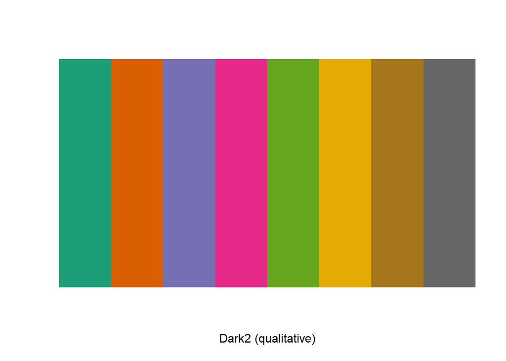

```r
display.brewer.pal(8, "Dark2")
```

```r
brewer.pal(5, "Dark2")
```

```
## [1] "#1B9E77" "#D95F02" "#7570B3" "#E7298A" "#66A61E"
```

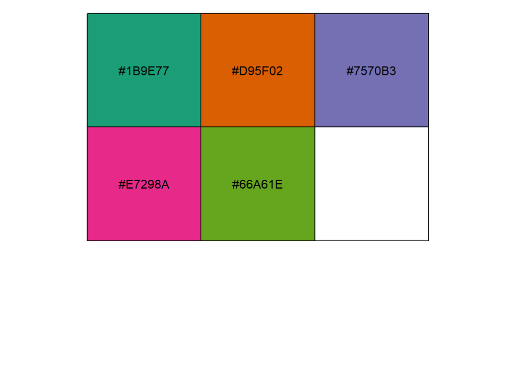

```r
show_col(brewer.pal(5, "Dark2"))
```

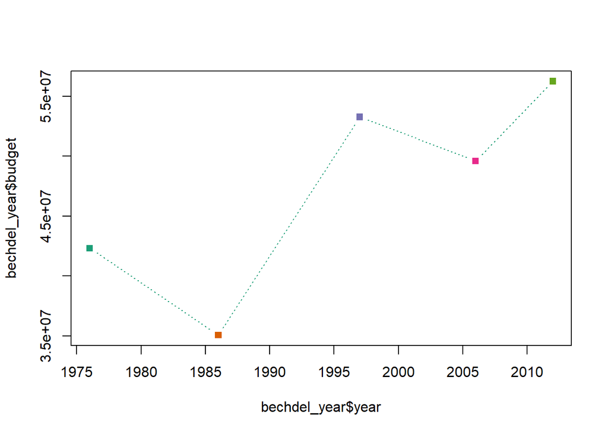

```r
plot(bechdel_year$year, bechdel_year$budget,  type="b",
     lty=3, pch=15,
     col=brewer.pal(5, "Dark2"))
```

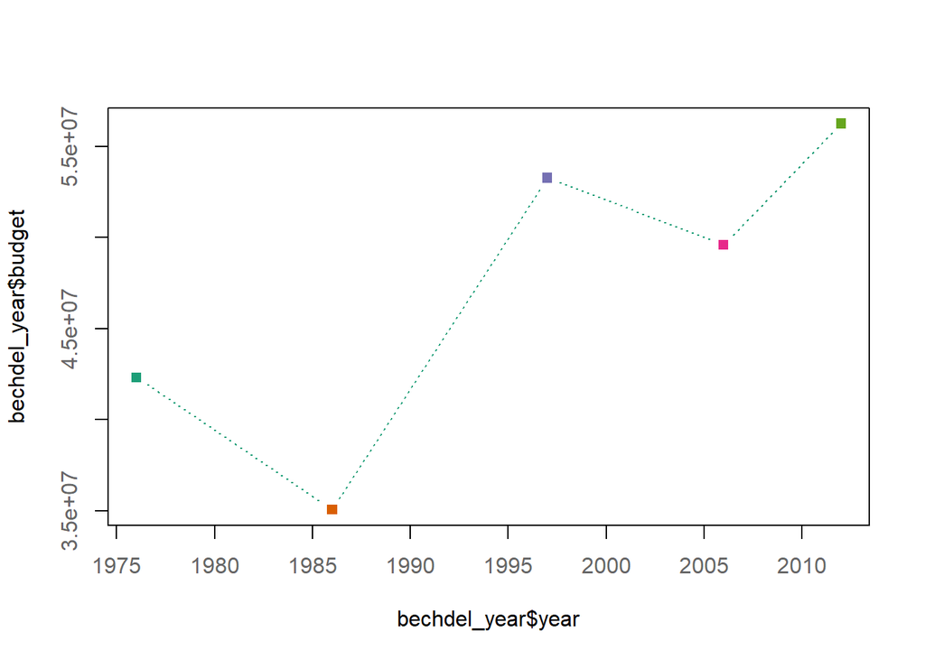

```r
plot(bechdel_year$year, bechdel_year$budget,  type="b",
     lty=3, pch=15,
     col=brewer.pal(5, "Dark2"), col.axis ="#666666")
```

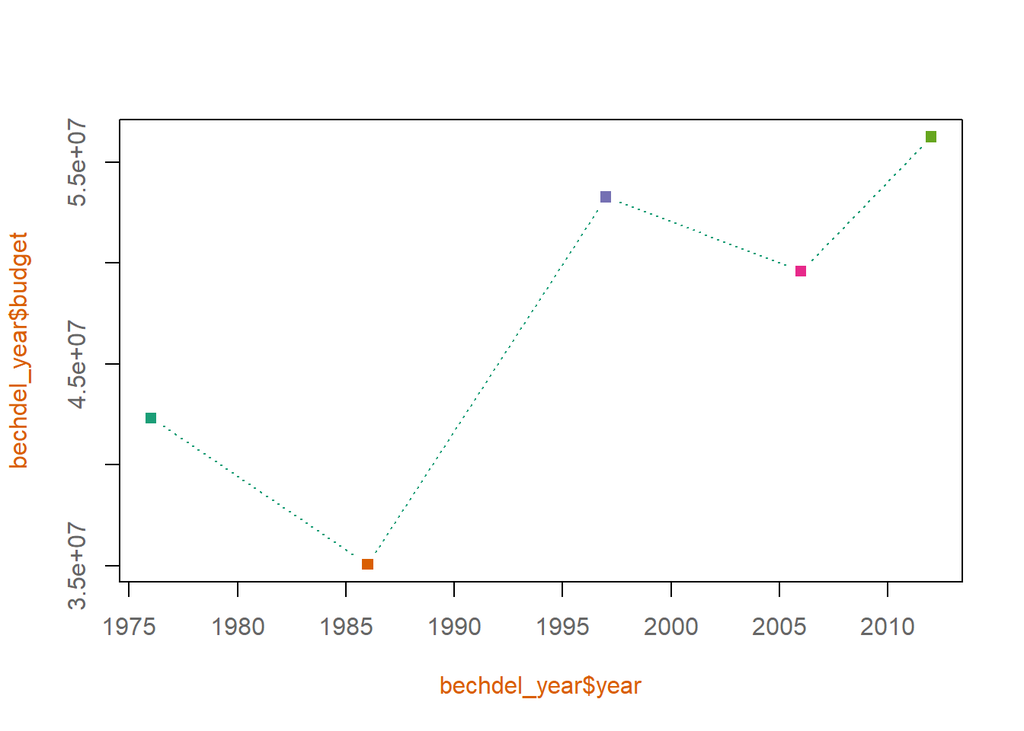

```r
plot(bechdel_year$year, bechdel_year$budget,  type="b",
     lty=3, pch=15,
     col=brewer.pal(5, "Dark2"), col.axis ="#666666", col.lab="#D95F02")
```

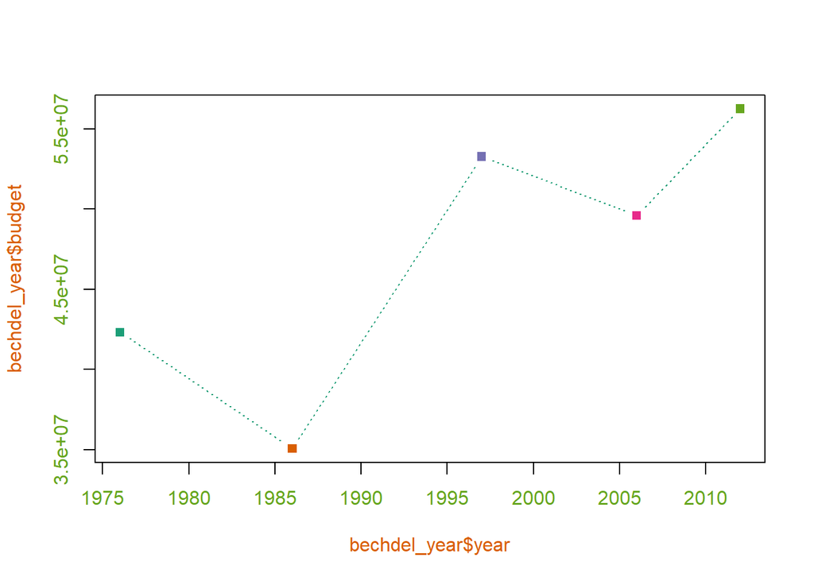

```r
plot(bechdel_year$year, bechdel_year$budget,  type="b",
     lty=3, pch=15,
     col=brewer.pal(5, "Dark2"), col.axis ="#666666", col.lab="#D95F02", col.axis ="#66A61E")
```

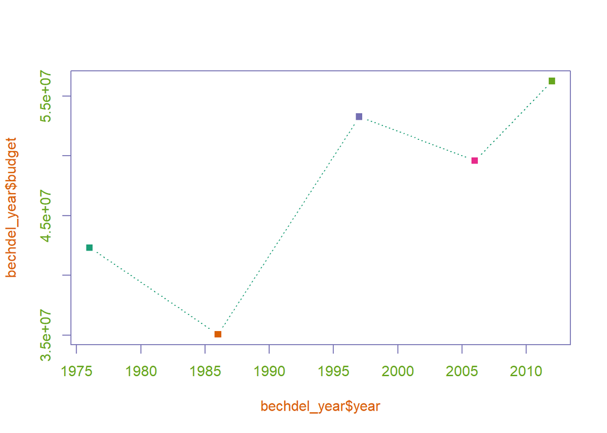

```r
plot(bechdel_year$year, bechdel_year$budget,  type="b",
     lty=3, pch=15,
     col=brewer.pal(5, "Dark2"), col.axis ="#666666", col.lab="#D95F02", col.axis ="#66A61E", fg="#7570B3")
```

# 5. Definição de parâmetros de gráficos: Texto

O texto pode ser acrescentado ao gráfico através dos argumentos main = “an overall title for the plot”, sub = “a sub title for the plot”, xlab = “a title for the x axis” e ylab = “a title for the y axis”.

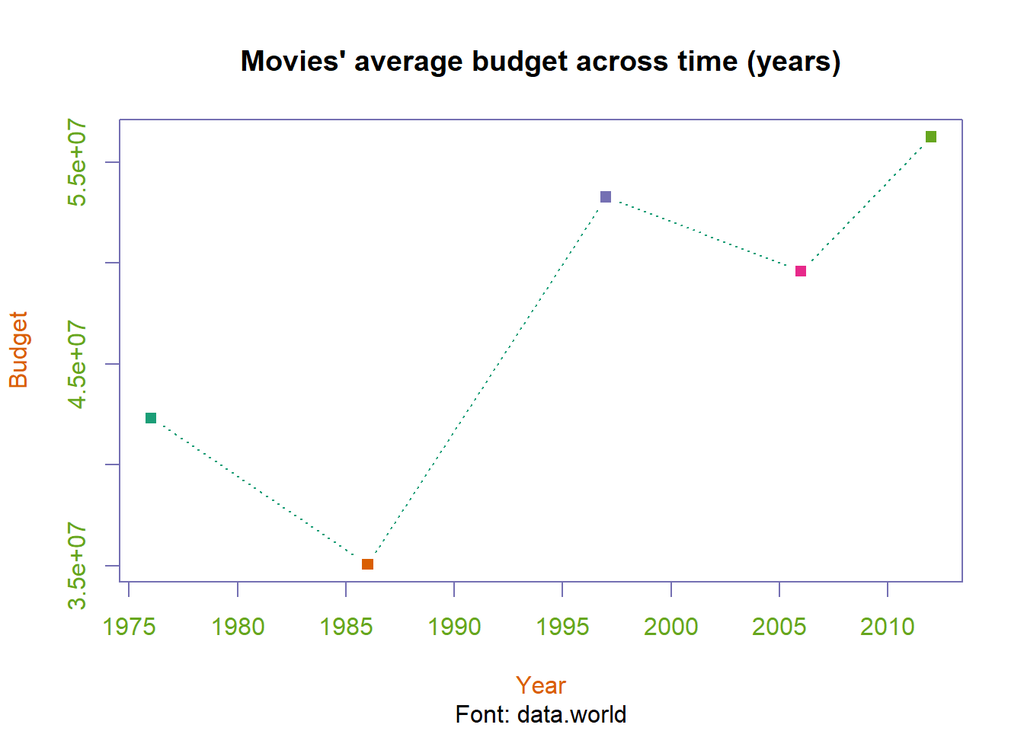

```r
plot(bechdel_year$year, bechdel_year$budget,  type="b",
     lty=3, pch=15,
     col=brewer.pal(5, "Dark2"), col.axis ="#666666", col.lab="#D95F02", col.axis ="#66A61E", fg="#7570B3",
     main = "Movies' average budget across time (years)", sub = "Font: data.world", xlab = "Year", ylab = "Budget")
```

A tabela seguinte apresenta os argumentos para definição do tamanho de texto em gráfico.

| Parâmetro | Descrição |
| --- | --- |
| cex | Tamanho do texto na área dos dados (relativo ao default = 1) |
| cex.axis | Tamanho do texto nos eixos (relativo a cex) |
| cex.lab | Tamanho dos labels (relativo a cex) |
| cex.main | Tamanho do título (relativo a cex) |
| cex.sub | Tamanho do subtítulo (relativo a cex) |

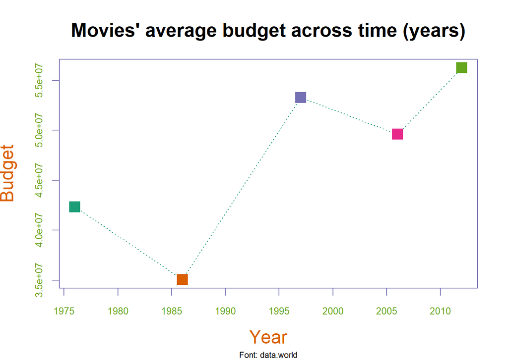

```r
plot(bechdel_year$year, bechdel_year$budget,  type="b",
     lty=3, pch=15,
     col=brewer.pal(5, "Dark2"), col.axis ="#666666", col.lab="#D95F02", col.axis ="#66A61E", fg="#7570B3",
     main = "Movies' average budget across time (years)", sub = "Font: data.world", xlab = "Year", ylab = "Budget",
     cex=2, cex.axis=.8, cex.lab=1.5, cex.main=1.6, cex.sub=.7)
```

A tabela seguinte apresenta os argumentos para definição da fonte e estilo do texto em gráfico.

| Parâmetro | Descrição |
| --- | --- |
| font | Número inteiro para especificar fonte do texto (1=normal, 2=negrito, 3=italico, 4=negrito e italico) |
| font.axis | Fonte do texto nos eixos (relativo a cex) |
| font.lab | Fonte dos labels (relativo a cex) |
| font.main | Fonte do título (relativo a cex) |
| font.sub | Fonte do subtítulo (relativo a cex) |
| ps | Tamanho dos pontos da fonte (default=1/72 inch). tamanho de texto = ps*cex |
| family | Família da fonte: serif, sans e mono |

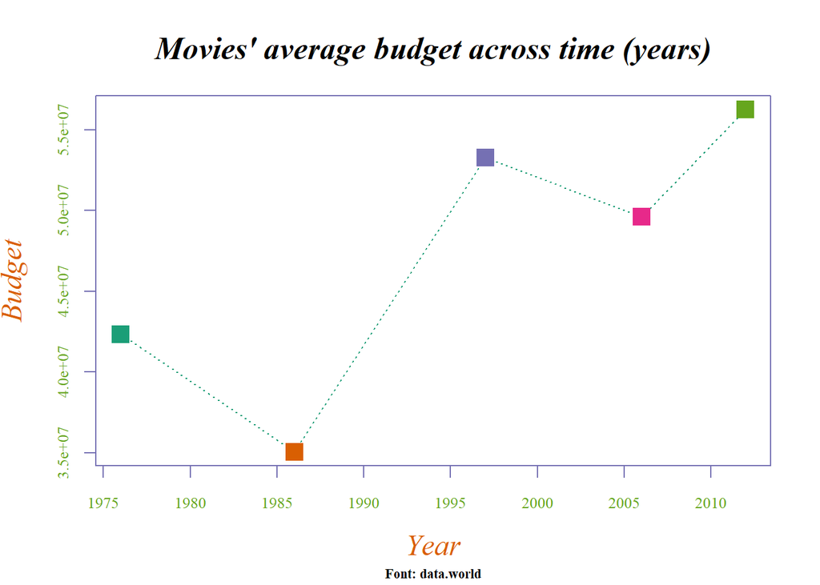

```r
plot(bechdel_year$year, bechdel_year$budget,  type="b",
     lty=3, pch=15,
     col=brewer.pal(5, "Dark2"), col.axis ="#666666", col.lab="#D95F02", col.axis ="#66A61E", fg="#7570B3",
     main = "Movies' average budget across time (years)", sub = "Font: data.world", xlab = "Year", ylab = "Budget",
     cex=2, cex.axis=.8, cex.lab=1.5, cex.main=1.6, cex.sub=.7,
     font.axis=1, font.lab=3, font.main=4, font.sub=2, family="serif")
```

É possivel chegar a um resultado semelhante ao anterior, passo a passo, usando as funções lines(), axis() e title

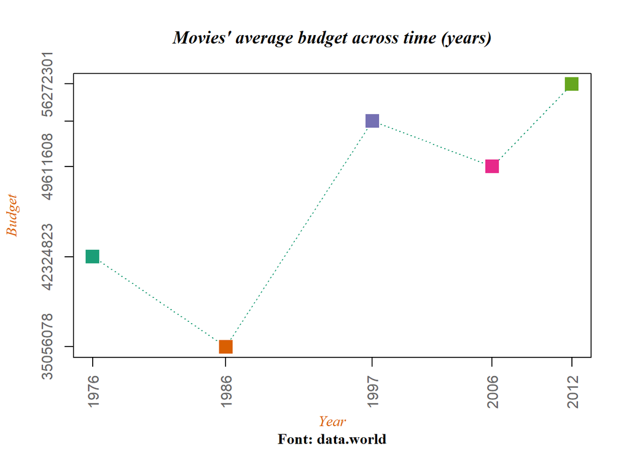

```r
plot(bechdel_year$year, bechdel_year$budget,
     axes=FALSE, frame.plot=TRUE, ann=FALSE)

lines(bechdel_year$year, bechdel_year$budget, type="b",
      lty=3, pch=15, col=brewer.pal(8, "Dark2"), cex=2)

axis(1, at=round(bechdel_year$year), xlab = "Year", col.axis ="#666666", las=2)
axis(2, at=bechdel_year$budge, ylab = "Budget", col.axis ="#666666")

title(main = "Movies' average budget across time (years)", sub = "Font: data.world", xlab = "Year", ylab = "Budget",
      col.axis ="#666666", col.lab="#D95F02",
      font.axis=1, font.lab=3, font.main=4, font.sub=2, family="serif")
```

# 6. Definição de parâmetros de gráficos: Dimensões

A tabela seguinte apresenta os argumentos para definição das dimensões do gráfico.

| Parâmetro | Descrição |
| --- | --- |
| pin | Dimensões do gráfico (largura e altura) em polegada (1 polegada = ~2.5cm) |
| mai | Vetor numérico com tamanho das margens em polegadas - c(inferior, esquerda, superior, direita) |

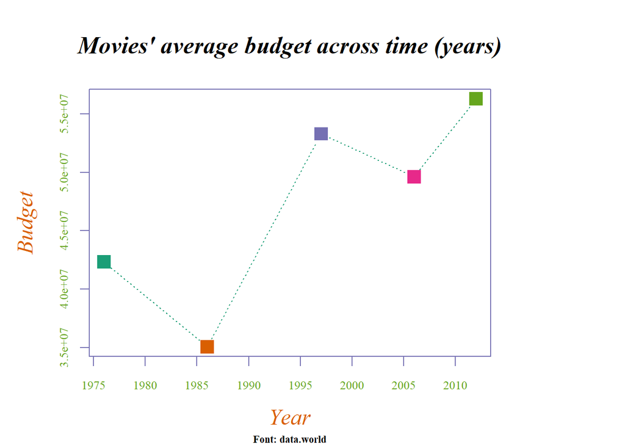

```r
par(pin=c(4,3), mai=c(1, 1, 1, 1.5))
plot(bechdel_year$year, bechdel_year$budget,  type="b",
     lty=3, pch=15,
     col=brewer.pal(5, "Dark2"), col.axis ="#666666", col.lab="#D95F02", col.axis ="#66A61E", fg="#7570B3",
     main = "Movies' average budget across time (years)", sub = "Font: data.world", xlab = "Year", ylab = "Budget",
     cex=2, cex.axis=.8, cex.lab=1.5, cex.main=1.6, cex.sub=.7,
     font.axis=1, font.lab=3, font.main=4, font.sub=2, family="serif")
```

# 7. Definição de parametros de gráficos: Linhas de referência

```r
names(bechdel_year)
```

```
## [1] "yeargroup"  "year"       "budget"     "US_profit"  "Int_profit"
```

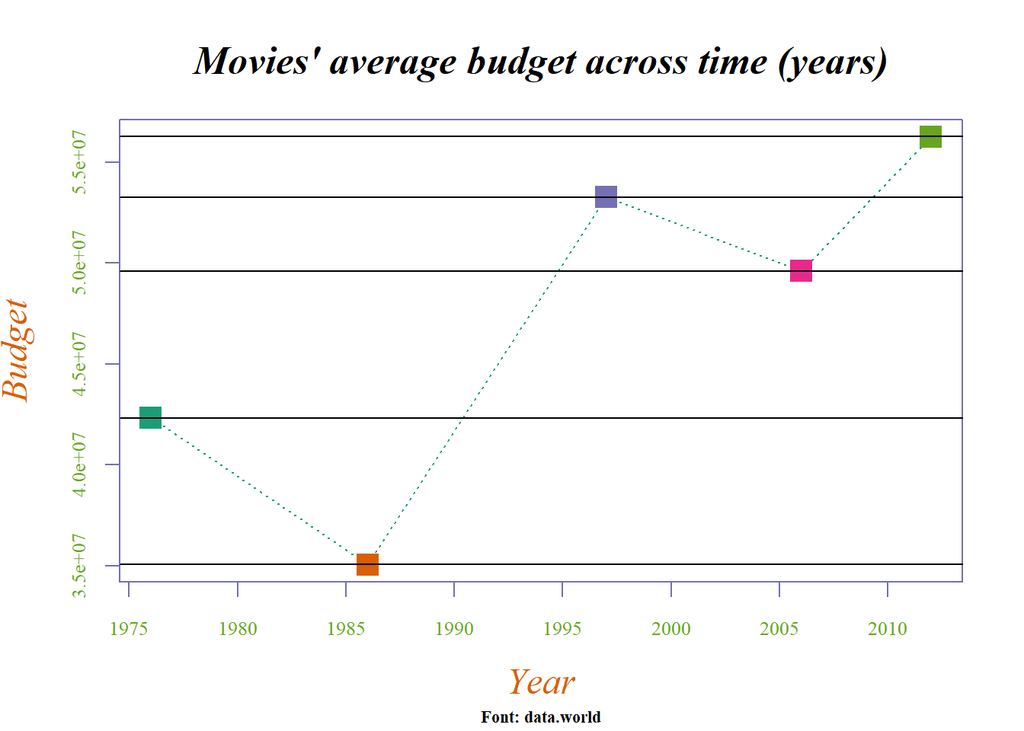

```r
plot(bechdel_year$year, bechdel_year$budget,  type="b",
     lty=3, pch=15,
     col=brewer.pal(5, "Dark2"), col.axis ="#666666", col.lab="#D95F02", col.axis ="#66A61E", fg="#7570B3",
     main = "Movies' average budget across time (years)", sub = "Font: data.world", xlab = "Year", ylab = "Budget",
     cex=2, cex.axis=.8, cex.lab=1.5, cex.main=1.6, cex.sub=.7,
     font.axis=1, font.lab=3, font.main=4, font.sub=2, family="serif")
abline(h=bechdel_year$budget)
```

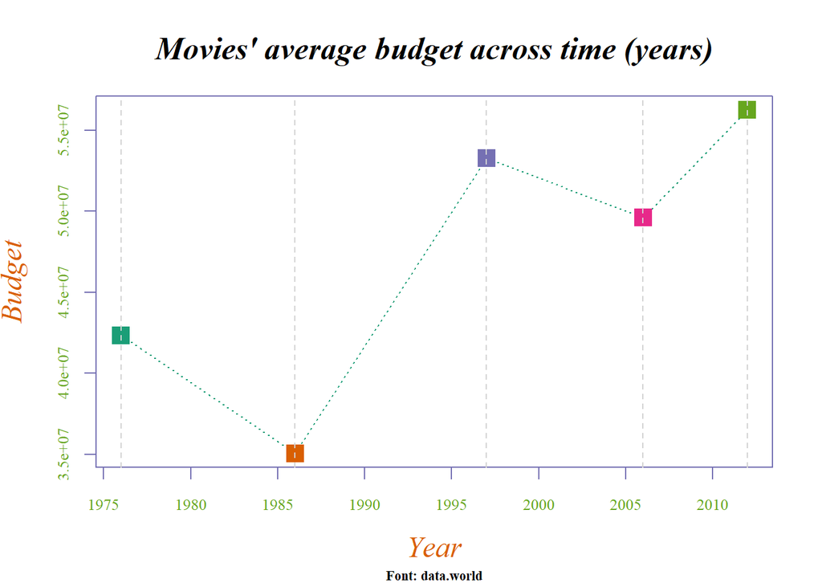

```r
plot(bechdel_year$year, bechdel_year$budget,  type="b",
     lty=3, pch=15,
     col=brewer.pal(5, "Dark2"), col.axis ="#666666", col.lab="#D95F02", col.axis ="#66A61E", fg="#7570B3",
     main = "Movies' average budget across time (years)", sub = "Font: data.world", xlab = "Year", ylab = "Budget",
     cex=2, cex.axis=.8, cex.lab=1.5, cex.main=1.6, cex.sub=.7,
     font.axis=1, font.lab=3, font.main=4, font.sub=2, family="serif")
abline(v=bechdel_year$year, lty=2, col="lightgrey")
```

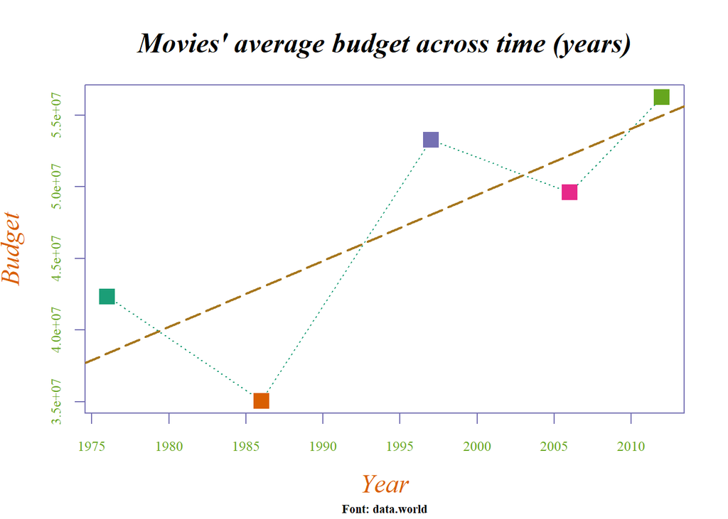

```r
plot(bechdel_year$year, bechdel_year$budget,  type="b",
     lty=3, pch=15,
     col=brewer.pal(5, "Dark2"), col.axis ="#666666", col.lab="#D95F02", col.axis ="#66A61E", fg="#7570B3",
     main = "Movies' average budget across time (years)", sub = "Font: data.world", xlab = "Year", ylab = "Budget",
     cex=2, cex.axis=.8, cex.lab=1.5, cex.main=1.6, cex.sub=.7,
     font.axis=1, font.lab=3, font.main=4, font.sub=2, family="serif")
abline(lm(bechdel_year$budget ~ bechdel_year$year), lty=5, lwd=2, col="#A6761D")
```

```r
#?abline
```